# Project 7- Linear Models with Many Variables

MTH 4053

11/1/2021

By Jake Bell

## Introduction:

In this project, I will be building Linear models with many predictors, in order to get increased accuracy compared to more basic linear models. Other tools that will be used will be correlation plots and AIC, to measure co-linearity and model performance.

We will be using two datasets, the 2018 World Happiness Report and 2018 Global Internet Usage, and building a model to identify a relationship between Internet Availability and Happiness scores. Internet availability shows how many people in each country access the internet, and happiness scores are calculated using a variety of metrics, such as GDP, corruption perceptions, and life expectancy.

**Goal:** Model the relationship between Internet Availability and World Happiness using Linear Models.

**Data Sources:**

- https://www.kaggle.com/unsdsn/world-happiness
- https://www.kaggle.com/tanuprabhu/list-of-countries-by-number-of-internet-users (2018 Data)

## Section 1: Prep Data

First we must load Necessary Packages

```r
library(tidyverse)
library(fastR2)
library(corrplot)
library(patchwork)
```

Now we load the 2 datasets for World Happiness and Internet Availability, and join it together.

```r
# Load Global Internet Usage dataset
InternetData <- read_csv("../Datasets/List_of_Countries_by_number_of_Internet_Users.csv") %>%
  rename(Country = "Country or Area",
         Population.Rank = Rank...4,
         Internet.Usage.Rank = Rank...6) %>%  # Rename columns to correct formatting
  filter( Internet.Usage.Rank != "-")

InternetData$Internet.Usage.Rank <- as.numeric(InternetData$Internet.Usage.Rank)


# Load Global Happiness dataset, changed missing U.A.E. corruption score to the mean in excel
HappinessData <- read_csv("../Datasets/World_Happiness_Report_2018.csv") %>%
  rename(Country = "Country or region",
         Happiness.Score = Score)


# Join together the 2 datasets
InternetHappinessData <- merge(x = InternetData, y = HappinessData, by = "Country") %>%
  rename_all(make.names)

head(InternetHappinessData)
```

|  | Country | Internet.Users | Population | Population.Rank | Percentage | Internet.Usage.Rank | Overall.rank | Happiness.Score | GDP.per.capita | Social.support | Healthy.life.expectancy | Freedom.to.make.life.choices | Generosity | Perceptions.of.corruption |
| --- | --- | --- | --- | --- | --- | --- | --- | --- | --- | --- | --- | --- | --- | --- |
| 1 | Afghanistan | 4068194 | 35530081 | 94 | 0.11 | 194 | 145 | 3.632 | 0.332 | 0.537 | 0.255 | 0.085 | 0.191 | 0.036 |
| 2 | Albania | 2105339 | 2930187 | 117 | 0.72 | 73 | 112 | 4.586 | 0.916 | 0.817 | 0.790 | 0.419 | 0.149 | 0.032 |
| 3 | Algeria | 19704622 | 41318142 | 36 | 0.48 | 130 | 84 | 5.295 | 0.979 | 1.154 | 0.687 | 0.077 | 0.055 | 0.135 |
| 4 | Angola | 4271053 | 29784193 | 92 | 0.14 | 186 | 142 | 3.795 | 0.730 | 1.125 | 0.269 | 0.000 | 0.079 | 0.061 |
| 5 | Argentina | 33561876 | 44271041 | 23 | 0.76 | 67 | 29 | 6.388 | 1.073 | 1.468 | 0.744 | 0.570 | 0.062 | 0.054 |
| 6 | Armenia | 2043110 | 2930450 | 118 | 0.70 | 78 | 129 | 4.321 | 0.816 | 0.990 | 0.666 | 0.260 | 0.077 | 0.028 |

Now that we have our data combined together and formatted for use, we will now beging to prepare for building our model.

## Section 2: Prep for Model

We will first look at some relationships in our data, in order to get a sense of what relationships in the data our model may follow.

### Visualize Relationships with Various graphs

Some relationships that I wanted to look at before building the model were seeing if Population size and Internet Usage had an effect on Happiness score.

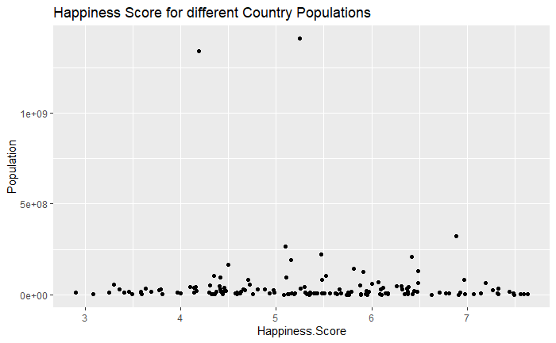

```r
# Size vs Happiness
gf_point(Population ~ Happiness.Score, data = InternetHappinessData,
         title = "Happiness Score for different Country Populations" )
```

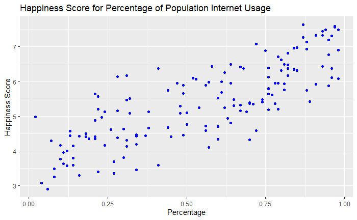

```r
# Look at Internet Percentage compared to happiness
gf_point(Happiness.Score ~ Percentage, data = InternetHappinessData, color = "blue",
         title = "Happiness Score for Percentage of Population Internet Usage")
```

There doesn’t appear to be much of a relationship between population size and happiness score, but many of the largest countries seem more concentrated in the middle ranges of the happiness scores. But looking at the relationship between % internet usage and Happiness score, we can see a clear correlation. This suggests to me that our model will look something like that positively correlated relationship.

### Use correlation plots to visualize relationships and identify colinearity.

Now that we have looked graphically at a few important relationships between some variables, we will look at all of the variables to see how they interact.

This will be done by using Correlation plots. We first set up our data only using numeric columns, since correlation plots don’t function with non-numeric data.

```r
IHDataNumeric <- InternetHappinessData %>%
  select( -Country)
```

In the website for the World Happiness Report, the Happiness score is constructed by summing up the other variables that were calculated for a particular country, like Social Support and Generosity. Due to this relationship, we will have to ignore these variables in our models

```r
# Not using variables included in the calculation of the happiness score
IHDataForModel <- IHDataNumeric %>%
  select( 0:5, 7)

head(IHDataForModel)
```

|  | Internet.Users | Population | Population.Rank | Percentage | Internet.Usage.Rank | Happiness.Score |
| --- | --- | --- | --- | --- | --- | --- |
| 1 | 4068194 | 35530081 | 94 | 0.11 | 194 | 3.632 |
| 2 | 2105339 | 2930187 | 117 | 0.72 | 73 | 4.586 |
| 3 | 19704622 | 41318142 | 36 | 0.48 | 130 | 5.295 |
| 4 | 4271053 | 29784193 | 92 | 0.14 | 186 | 3.795 |
| 5 | 33561876 | 44271041 | 23 | 0.76 | 67 | 6.388 |
| 6 | 2043110 | 2930450 | 118 | 0.70 | 78 | 4.321 |

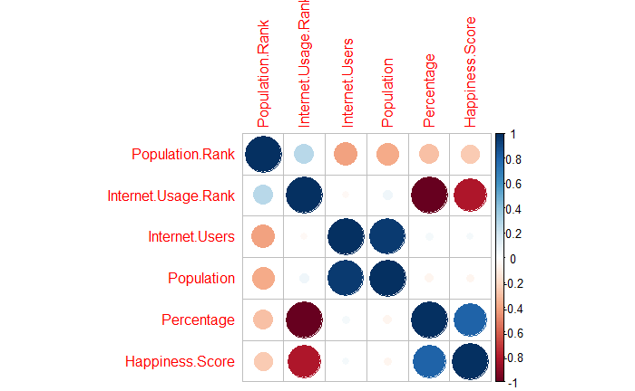

```r
# make correlation matrix
IHDataCorr2 <- cor(IHDataForModel, use = 'pairwise.complete.obs')

corrplot( IHDataCorr2, order = 'hclust')
```

Looking at this correlation plot, we can see a few highly correlated variables

- Percentage <-> Internet.Usage.Rank
- Happiness.score <-> Internet.Usage.Rank
- Population <-> Internet.Users

## Section 3: Building Linear Models

We will now build Linear models using various combinations of model variables.

### Using Stepwise Regression to pick only useful variables.

One method that automatically picks the best variables to use in the model is called Stepwise Regression. We will use this method as an alternative to looking at the correlation plot and manually picking variables to use.

First here is a basic linear model using all of our available data.

```r
# Make our basic linear model
IHModel <- lm( Happiness.Score ~ Internet.Users + Population + Population.Rank + Percentage +
                  Internet.Usage.Rank,
                data = IHDataNumeric)
# Get score of linear model
summary(IHModel)
```

```
Call:
lm(formula = Happiness.Score ~ Internet.Users + Population +
    Population.Rank + Percentage + Internet.Usage.Rank, data = IHDataNumeric)

Residuals:
     Min       1Q   Median       3Q      Max
-1.45679 -0.46976 -0.03966  0.54782  1.58291

Coefficients:
                      Estimate Std. Error t value Pr(>|t|)
(Intercept)          6.273e+00  2.260e+00   2.775  0.00625 **
Internet.Users       1.979e-09  2.801e-09   0.706  0.48102
Population          -9.947e-10  1.318e-09  -0.754  0.45184
Population.Rank     -8.379e-04  1.405e-03  -0.596  0.55198
Percentage           6.970e-01  2.159e+00   0.323  0.74729
Internet.Usage.Rank -1.135e-02  1.001e-02  -1.135  0.25832
---
Signif. codes:  0 ‘***’ 0.001 ‘**’ 0.01 ‘*’ 0.05 ‘.’ 0.1 ‘ ’ 1

Residual standard error: 0.6844 on 144 degrees of freedom
Multiple R-squared:  0.6468,    Adjusted R-squared:  0.6345
F-statistic: 52.74 on 5 and 144 DF,  p-value: < 2.2e-16
```

This model obtained a Adjusted R-squared of 0.6345, which is not bad performance.

Now we will use stepwise regression to pick only relevant variables and get the performance. The way that performance is analyzed is using the Akaike Information Criterion (AIC), and essentially the lower the score is the better.

```r
IHModelStep <- step(IHModel, trace = FALSE)

summary(IHModelStep)
```

```
Call:
lm(formula = Happiness.Score ~ Internet.Usage.Rank, data = IHDataNumeric)

Residuals:
     Min       1Q   Median       3Q      Max
-1.48320 -0.50551 -0.02147  0.54869  1.55580

Coefficients:
                      Estimate Std. Error t value Pr(>|t|)
(Intercept)          6.9780433  0.1121876   62.20   <2e-16 ***
Internet.Usage.Rank -0.0150493  0.0009205  -16.35   <2e-16 ***
---
Signif. codes:  0 ‘***’ 0.001 ‘**’ 0.01 ‘*’ 0.05 ‘.’ 0.1 ‘ ’ 1

Residual standard error: 0.6781 on 148 degrees of freedom
Multiple R-squared:  0.6436,    Adjusted R-squared:  0.6412
F-statistic: 267.3 on 1 and 148 DF,  p-value: < 2.2e-16
```

The AIC’s were negative, and they got lower and lower through each cycle of the stepwise regression. Our refined model got an Adusted R-squared of 0.6412, which is greater than our original model’s score of 0.6345.

It is also surprising that the model that was decided through stepwise regression only included one variable, Internet.Usage.Rank, and that that single variable predicted it best.

### Visualize the Linear Models and Residuals

We will now see how our models predict the data visually and if there are any glaring errors/patterns.

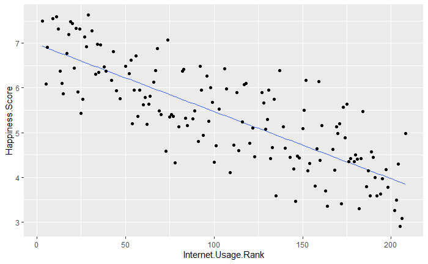

```r
# Plot stepwise regression model
gf_lm(Happiness.Score ~ Internet.Usage.Rank, data = IHDataNumeric) %>%
  gf_point(Happiness.Score ~ Internet.Usage.Rank)
```

One way to look for any errors in the model is to to analyze the residual plot of the data. We will calculate and plot the residuals, and look to make sure that the distribution of residuals is random about the x-axis.

```r
# Calculate and plot Residuals
IHDataStep <- IHDataForModel %>%
  mutate(Predictions = fitted(IHModelStep),
         Residuals = resid(IHModelStep))

head(IHDataStep)
```

|  | Internet.Users | Population | Population.Rank | Percentage | Internet.Usage.Rank | Happiness.Score | Predictions | Residuals |
| --- | --- | --- | --- | --- | --- | --- | --- | --- |
| 1 | 4068194 | 35530081 | 94 | 0.11 | 194 | 3.632 | 4.058472 | -0.4264720 |
| 2 | 2105339 | 2930187 | 117 | 0.72 | 73 | 4.586 | 5.879442 | -1.2934418 |
| 3 | 19704622 | 41318142 | 36 | 0.48 | 130 | 5.295 | 5.021630 | 0.2733704 |
| 4 | 4271053 | 29784193 | 92 | 0.14 | 186 | 3.795 | 4.178867 | -0.3838667 |
| 5 | 33561876 | 44271041 | 23 | 0.76 | 67 | 6.388 | 5.969738 | 0.4182622 |
| 6 | 2043110 | 2930450 | 118 | 0.70 | 78 | 4.321 | 5.804195 | -1.4831951 |

[figure not shown]

```r
gf_point(Residuals ~ Predictions, data = IHDataStep) %>%
  gf_line(y=0, alpha = .75, color = "blue")
```

Looking at the residuals, they appear randomly distributed, so there are no apparent errors in our model. It appears that our linear model is a good fit of the data.

## Section 4: Comparing Our Models

Get scores of the model using AIC and pick the best one. As a reminder, AIC is short for “Akaike’s Information Criteria” and it is used to compare different models fit to the same data. When interpreting the score, smaller scores are better.

```r
cat("AIC of Linear Model using all possible variables: ", round( AIC(IHModel), 2))
```

```
AIC of Linear Model using all possible variables:  319.78
```

```r
cat("\nAIC of Linear Model using selected variables:     ", round( AIC(IHModelStep), 2))
```

```
AIC of Linear Model using selected variables:      313.11
```

Looking at the AIC scores, we can see that the stepwise regression linear model performed better.

Let’s get a confidence interval for the relationship between Internet usage rank and Happiness score.

```r
confint(IHModelStep)
```

```
                          2.5 %      97.5 %
(Intercept)          6.75634682  7.19973984
Internet.Usage.Rank -0.01686829 -0.01323039
```

For every increase in Internet Usage Rank, we can be 95% confident that the true change in happiness is between [-0.017 and -0.013].

## Section 5: Results and Conclusion

So what does this tell us about the relationship between Internet Availability and Happiness?

**Countries with higher Internet Usage have greater Happiness scores.**

In our model for predicting the Happiness Score of a country given data on the internet availability in that country, there was a positive correlation between internet availability and happiness score, and we saw that the higher the rank of internet availability was, the higher the happiness score was.

Since the happiness score is comprised of variables like GDP per capita and Social support, it is not surprising to see that countries that have higher access to internet also have more money to spend to improve life in other ways. This does not mean that having higher internet access increases happiness, but that they often are both present together.